# hw1

ww5_weiwang

February 11, 2019

```r
loadlibs = function(libs) {
  for(lib in libs) {
    class(lib)
    if(!do.call(require,as.list(lib))) {install.packages(lib)}
    do.call(require,as.list(lib))
  }
}
libs = c("tidyr","magrittr","purrr","dplyr","stringr","readr","data.table", "lubridate","crossval","eeptools","rpart","rpart.plot","caret","plotROC","pROC","ROCR")
loadlibs(libs)
```

## (1) Your own decision tree [6]

Preperation of the data

```r
#--- synthetic depression data
depressionData = data.frame(
  # do not modify the data in "depressionData"
  pregnant = c(1,0,1,1),
  depressed = c("yes","yes","no","no") %>% as.factor(),
  age = c(18, 40, 35, 21),
  hospitalized = c(1, 0, 0, 0) %>% as.logical()
) %>% tbl_df()
```

1. debug the function, get odds value

```r
#--- tree: a model that outputs the odds of hospitalization from inputs of data (datums)
tree = data.frame( # do not change "tree"
  splitVariable = c("depressed", "pregnant", NA, NA, NA),
  split = c("yes", 1, NA, NA, NA),
  trueChild = c(2, 4, NA, NA, NA),
  falseChild = c(3, 5, NA, NA, NA),
  odds = c(NA, NA, 0.1, 2, 3)
)

predictOddsOnDataSet = function(tree, data, active = 1) {
  apply(data, 1, (function(x) {predictedOdds(tree=tree, x, active=1)})  )
}

predictedOdds = function(tree, datum, active = 1) {

  if(is.na(tree[active,"splitVariable"])) {
    # leaf of tree, so output value
    return(tree$odds[active])

  } else {
    # internal node of tree, so continue down tree to true/false child
    if( (datum[[tree[active,"splitVariable"] %>% as.character]] %>% as.character) == tree[active,"split"])
      return(predictedOdds(tree, datum, active = tree[active,"trueChild"]))

    else
      return(predictedOdds(tree, datum, active = tree[active,"falseChild"]))

  }

}

predictOddsOnDataSet(tree, depressionData)
```

```
## [1] 2.0 3.0 0.1 0.1
```

2. Add two columns, `odds` and `probability` to `depressionData` that give you the predicted odds and probabilities of hospitalization. Print the result.

```r
depressionData$odds=predictOddsOnDataSet(tree,depressionData)
depressionData$probability=depressionData$odds/(depressionData$odds+1)
depressionData
```

```
## # A tibble: 4 x 6
##   pregnant depressed   age hospitalized  odds probability
##      <dbl> <fct>     <dbl> <lgl>        <dbl>       <dbl>
## 1        1 yes          18 TRUE           2        0.667
## 2        0 yes          40 FALSE          3        0.75
## 3        1 no           35 FALSE          0.1      0.0909
## 4        1 no           21 FALSE          0.1      0.0909
```

3. Using a threshold probability of 0.5, what is: acc = (TP+TN)/(FP+TN+TP+FN); sens = TP/(TP+FN); spec = TN/(FP+TN) ppv = TP/(FP+TP); npv = TN/(TN+FN)

```r
predict1 = function(prob){
  result=rep(NA, length(prob))
  for (i in 1:length(prob)) {
    print(prob[i])
    if(prob[i]>=0.5){
      result[i]=TRUE
    }else{
      result[i]=FALSE
    }
  }
  return(result)
}
#actual value
actual=depressionData$hospitalized
#predict value
predict_h=predict1(depressionData$probability)
```

```
## [1] 0.6666667
## [1] 0.75
## [1] 0.09090909
## [1] 0.09090909
```

```r
cm=confusionMatrix(table(predict_h,actual),negative=FALSE)
cm
```

```
## Confusion Matrix and Statistics
##
##          actual
## predict_h FALSE TRUE
##     FALSE     2    0
##     TRUE      1    1
##
##                Accuracy : 0.75
##                  95% CI : (0.1941, 0.9937)
##     No Information Rate : 0.75
##     P-Value [Acc > NIR] : 0.7383
##
##                   Kappa : 0.5
##  Mcnemar's Test P-Value : 1.0000
##
##             Sensitivity : 0.6667
##             Specificity : 1.0000
##          Pos Pred Value : 1.0000
##          Neg Pred Value : 0.5000
##              Prevalence : 0.7500
##          Detection Rate : 0.5000
##    Detection Prevalence : 0.5000
##       Balanced Accuracy : 0.8333
##
##        'Positive' Class : FALSE
##
```

```r
modifyTree = function(tree, row, split_string, trueChildOdds, falseChildOdds){
  split_name=substr(split_string,1,3)
  split_num=substr(split_string,7,nchar(split_string))

  tree$splitVariable=as.character(tree$splitVariabl)
  tree$split=as.character(tree$split)
  tree$splitVariable[row]=as.character(split_name)
  tree$split[row]=as.numeric(split_num)
  tree$odds[row]=NA
  tree$trueChild[row]=length(tree)+1
  tree$falseChild[row]=length(tree)+2

  tree = rbind(tree,c(NA,NA,NA,NA,trueChildOdds))
  tree = rbind(tree,c(NA,NA,NA,NA,falseChildOdds))
  return(tree)
}
tree=modifyTree(tree, 3, "age < 21", 0.1, 1)
tree
```

```
##   splitVariable split trueChild falseChild odds
## 1     depressed   yes         2          3   NA
## 2      pregnant     1         4          5   NA
## 3           age    21         6          7   NA
## 4          <NA>  <NA>        NA         NA  2.0
## 5          <NA>  <NA>        NA         NA  3.0
## 6          <NA>  <NA>        NA         NA  0.1
## 7          <NA>  <NA>        NA         NA  1.0
```

## (2) Applying logistic regression for association and prediction [14]

#### Subsection 1. [6]

1. State and justify your chosen unit of analysis (e.g. person, hospitalization), and then preprocess the data accordingly. Report descriptive statistics by summarizing each of the features above and the outcome.

For most of the columns, the result is good distributed without much outliers, while when I plot for icustay total numer, it shows that most of the num are aggregate at 1, also for barplot, there are several category very concentrate. The age of death shows a left skew, which indicates most of the patients are elders.

```r
###preprocessing the data
icustay=read.csv("icustay_detail.csv",header = TRUE)
demo=read.csv("demographic_detail.csv",header = TRUE)
icd=read.csv("icd9.csv",header = TRUE)

icustay=icustay[c("icustay_id","subject_id","icustay_admit_age","gender","hadm_id","icustay_total_num","hospital_expire_flg","dob","dod")]
demo=demo[c("subject_id","ethnicity_descr","overall_payor_group_descr","admission_type_descr","admission_source_descr")]

new_table=icustay %>% left_join(demo, by="subject_id")

icd = icd %>%
  group_by(subject_id,hadm_id) %>%
  summarise(ttlCode=length(code)) %>%
  arrange(subject_id,hadm_id) %>% as.data.frame()
new_table = left_join(new_table,icd,by=c("subject_id","hadm_id"))
new_table = new_table %>%
  group_by(subject_id) %>%
  mutate(number_hadm = seq(1,length(hadm_id)),
         number_code = cumsum(ttlCode)) %>% as.data.frame()

newdata=unique(new_table)
newdata$age_death=age_calc(as.Date(newdata$dob),as.Date(newdata$dod),units = "years",precise = FALSE)
summary(newdata)
```

```
##    icustay_id      subject_id    icustay_admit_age  gender
##  Min.   :    4   Min.   :    3   Min.   :  0.00    F   :5252
##  1st Qu.:11836   1st Qu.: 9055   1st Qu.: 46.18    M   :6784
##  Median :19224   Median :13355   Median : 65.71    NA's:  13
##  Mean   :19758   Mean   :14182   Mean   : 63.10
##  3rd Qu.:26661   3rd Qu.:19213   3rd Qu.: 78.17
##  Max.   :47473   Max.   :32763   Max.   :105.34
##
##     hadm_id      icustay_total_num hospital_expire_flg
##  Min.   :    2   Min.   : 1.000    N   :8753
##  1st Qu.: 7215   1st Qu.: 1.000    Y   :2111
##  Median :14842   Median : 1.000    NA's:1185
##  Mean   :14961   Mean   : 1.812
##  3rd Qu.:22527   3rd Qu.: 1.000
##  Max.   :36103   Max.   :15.000
##  NA's   :1185
##                   dob                        dod
##  3379-02-09 00:00:00:1551   3418-11-29 00:00:00:1551
##  2597-11-09 00:00:00: 624   2635-07-24 00:00:00: 624
##  2473-02-02 00:00:00: 156   2538-08-24 00:00:00: 156
##  2611-12-30 00:00:00: 108   2675-04-21 00:00:00: 108
##  3111-06-30 00:00:00:  88   3207-09-03 00:00:00:  88
##  3273-05-23 00:00:00:  81   3333-04-05 00:00:00:  81
##  (Other)            :9441   (Other)            :9441
##                ethnicity_descr    overall_payor_group_descr
##  WHITE                 :7035   MEDICARE        :7892
##  BLACK/AFRICAN AMERICAN:3360   PRIVATE         :1919
##  UNKNOWN/NOT SPECIFIED : 961   MEDICAID        : 969
##  HISPANIC OR LATINO    : 170   MEDICARE-PRIVATE: 833
##  ASIAN                 : 164   OTHER           : 248
##  (Other)               : 325   (Other)         : 154
##  NA's                  :  34   NA's            :  34
##  admission_type_descr               admission_source_descr    ttlCode
##  ELECTIVE :  759      EMERGENCY ROOM ADMIT     :8657       Min.   : 1.00
##  EMERGENCY:10867      TRANSFER FROM HOSP/EXTRAM:1621       1st Qu.: 9.00
##  NEWBORN  :   27      PHYS REFERRAL/NORMAL DELI:1178       Median : 9.00
##  URGENT   :  362      CLINIC REFERRAL/PREMATURE: 358       Mean   :11.02
##  NA's     :   34      TRANSFER FROM SKILLED NUR: 160       3rd Qu.:13.00
##                       (Other)                  :  41       Max.   :39.00
##                       NA's                     :  34       NA's   :1200
##   number_hadm    number_code       age_death
##  Min.   :   1   Min.   :   1.0   Min.   :  0.00
##  1st Qu.:   1   1st Qu.:  10.0   1st Qu.: 47.00
##  Median :   4   Median :  35.0   Median : 66.00
##  Mean   : 123   Mean   : 690.1   Mean   : 64.01
##  3rd Qu.:  25   3rd Qu.: 194.8   3rd Qu.: 79.00
##  Max.   :1551   Max.   :8382.0   Max.   :105.00
##                 NA's   :1231
```

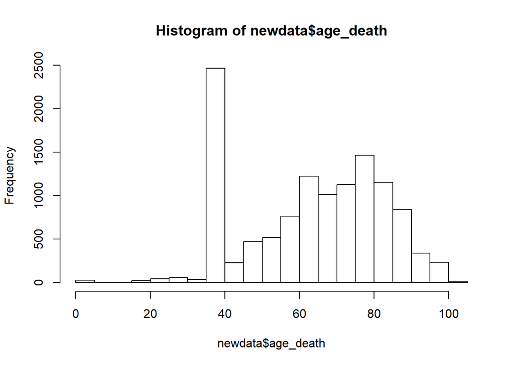

```r
hist(newdata$age_death)
```

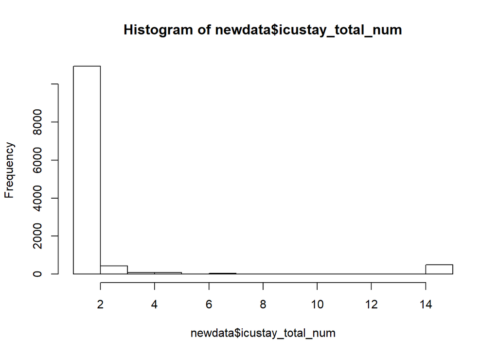

```r
hist(newdata$icustay_total_num)
```

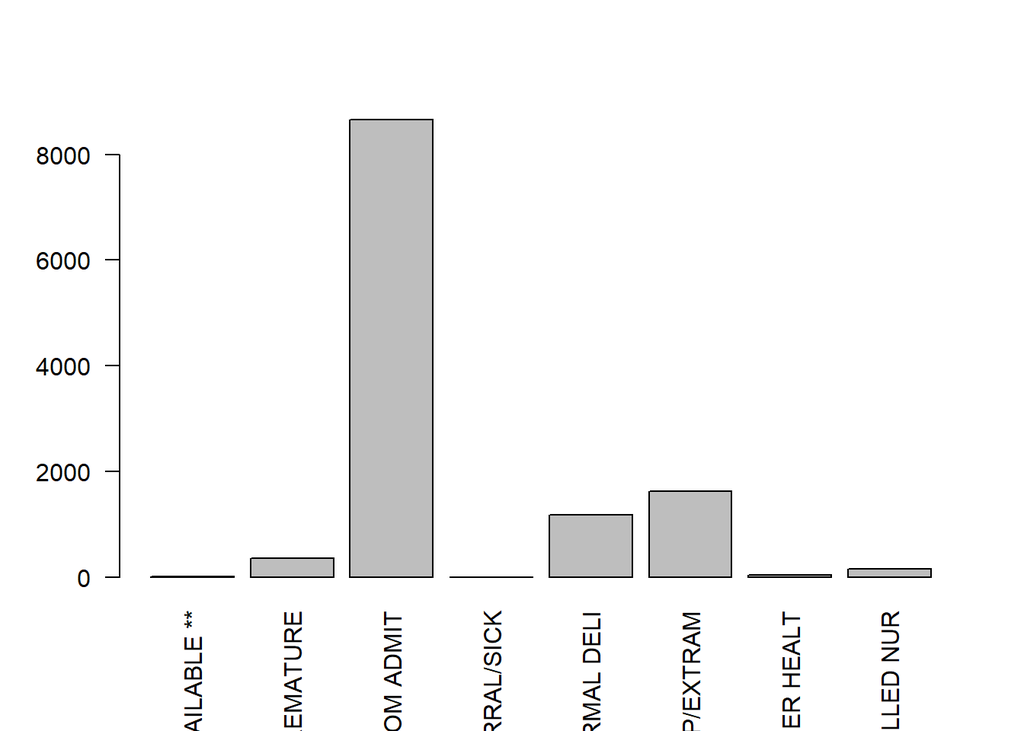

```r
barplot(table(newdata$admission_source_descr),las=2)
```

```r
#seperate train and test data
newdata = newdata[sample(1:nrow(newdata)),]
lr_train = newdata[1:8000,]
lr_train=na.omit(lr_train)
lr_test = newdata[-(1:8000),]
lr_test = na.omit(lr_test)
```

2. Use and interpret logistic regression using only the features: (1) age at ICU admission, (2) gender, and (3) type of admission. In a sentence, make a precise, interpretive statement about the relationship of age and in-hospital death for this model.

```r
#conduct logistic model
mylogit <- glm(hospital_expire_flg~icustay_admit_age+gender+admission_type_descr+ttlCode,data = lr_train, family = binomial("logit"))
mylogit %>% summary()
```

```
##
## Call:
## glm(formula = hospital_expire_flg ~ icustay_admit_age + gender +
##     admission_type_descr + ttlCode, family = binomial("logit"),
##     data = lr_train)
##
## Deviance Residuals:
##     Min       1Q   Median       3Q      Max
## -1.2294  -0.7013  -0.5682  -0.4185   2.4578
##
## Coefficients:
##                                 Estimate Std. Error z value Pr(>|z|)
## (Intercept)                    -3.914709   0.196630 -19.909  < 2e-16 ***
## icustay_admit_age               0.024322   0.001821  13.354  < 2e-16 ***
## genderM                        -0.076982   0.061803  -1.246  0.21291
## admission_type_descrEMERGENCY   0.371442   0.132851   2.796  0.00518 **
## admission_type_descrNEWBORN    16.995558 154.139294   0.110  0.91220
## admission_type_descrURGENT      0.614517   0.208403   2.949  0.00319 **
## ttlCode                         0.046415   0.005591   8.302  < 2e-16 ***
## ---
## Signif. codes:  0 '***' 0.001 '**' 0.01 '*' 0.05 '.' 0.1 ' ' 1
##
## (Dispersion parameter for binomial family taken to be 1)
##
##     Null deviance: 7015.7  on 7198  degrees of freedom
## Residual deviance: 6683.8  on 7192  degrees of freedom
## AIC: 6697.8
##
## Number of Fisher Scoring iterations: 12
```

3. State a use case for using the logistic regression model or the results from the model (one sentence). A well-described use case includes a description of intended users, temporal/situational/contextual constraints, and how the model or results may provide value. Given this use case, state which of the above features you should and should not use (one sentence). Briefly explain why (one sentence). Re-run logistic regression (and preprocessing as necessary) based on the features that support your use case and report the summary.

```r
mylogit2 <- glm(hospital_expire_flg~icustay_admit_age+gender+admission_type_descr+overall_payor_group_descr+ttlCode,data = lr_train, family = binomial("logit"))
mylogit2 %>% summary()
```

```
##
## Call:
## glm(formula = hospital_expire_flg ~ icustay_admit_age + gender +
##     admission_type_descr + overall_payor_group_descr + ttlCode,
##     family = binomial("logit"), data = lr_train)
##
## Deviance Residuals:
##     Min       1Q   Median       3Q      Max
## -1.9509  -0.7106  -0.5551  -0.3311   2.5141
##
## Coefficients:
##                                             Estimate Std. Error z value
## (Intercept)                                -3.136936   0.450618  -6.961
## icustay_admit_age                           0.031197   0.002168  14.387
## genderM                                    -0.120681   0.062869  -1.920
## admission_type_descrEMERGENCY               0.398058   0.133357   2.985
## admission_type_descrNEWBORN                16.822600 147.183110   0.114
## admission_type_descrURGENT                  0.581408   0.209197   2.779
## overall_payor_group_descrFREE CARE         -0.445933   0.528166  -0.844
## overall_payor_group_descrMEDICAID          -0.932159   0.415592  -2.243
## overall_payor_group_descrMEDICARE          -1.515194   0.400013  -3.788
## overall_payor_group_descrMEDICARE-PRIVATE  -1.204731   0.411814  -2.925
## overall_payor_group_descrOTHER             -1.223820   0.443073  -2.762
## overall_payor_group_descrPRIVATE           -0.716406   0.404153  -1.773
## overall_payor_group_descrSELF-PAY           1.675482   0.616362   2.718
## ttlCode                                     0.048199   0.005638   8.548
##                                           Pr(>|z|)
## (Intercept)                               3.37e-12 ***
## icustay_admit_age                          < 2e-16 ***
## genderM                                   0.054912 .
## admission_type_descrEMERGENCY             0.002837 **
## admission_type_descrNEWBORN               0.909002
## admission_type_descrURGENT                0.005449 **
## overall_payor_group_descrFREE CARE        0.398500
## overall_payor_group_descrMEDICAID         0.024899 *
## overall_payor_group_descrMEDICARE         0.000152 ***
## overall_payor_group_descrMEDICARE-PRIVATE 0.003440 **
## overall_payor_group_descrOTHER            0.005743 **
## overall_payor_group_descrPRIVATE          0.076293 .
## overall_payor_group_descrSELF-PAY         0.006561 **
## ttlCode                                    < 2e-16 ***
## ---
## Signif. codes:  0 '***' 0.001 '**' 0.01 '*' 0.05 '.' 0.1 ' ' 1
##
## (Dispersion parameter for binomial family taken to be 1)
##
##     Null deviance: 7015.7  on 7198  degrees of freedom
## Residual deviance: 6537.1  on 7185  degrees of freedom
## AIC: 6565.1
##
## Number of Fisher Scoring iterations: 12
```

#### Subsection 2. [5]

4. Fit a decision tree and plot the tree.

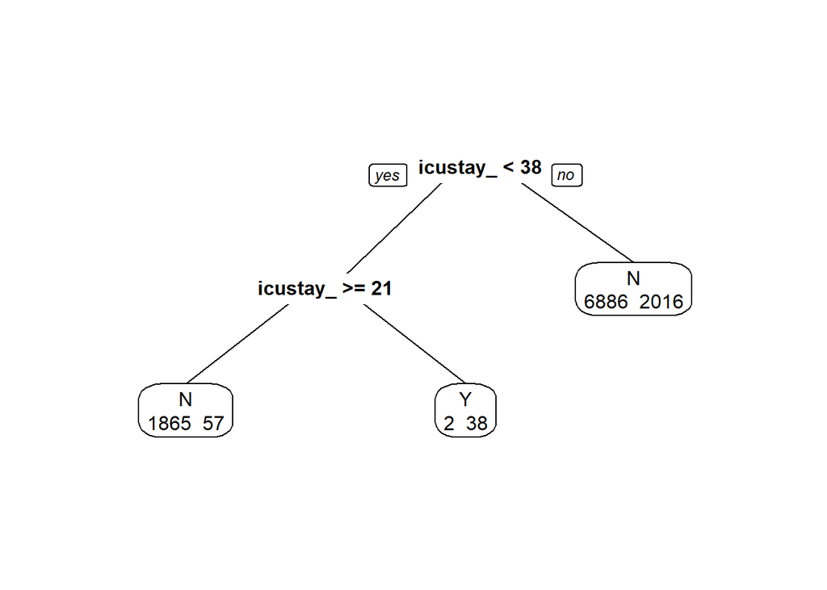

```r
#decision_tree
tc <- rpart.control(minsplit = 20, minbucket = 10, maxdepth = 5, xval = 5, cp = 0.005)
tree_result=rpart(hospital_expire_flg ~ icustay_admit_age+gender+admission_type_descr+overall_payor_group_descr+ttlCode, data = newdata, control = tc)
prp(tree_result,extra = 1)
```

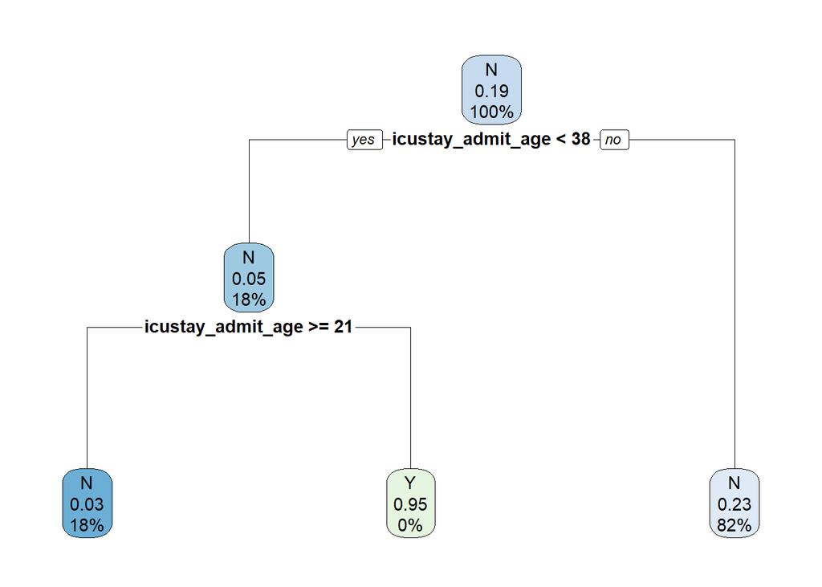

```r
rpart.plot(tree_result,cex = 0.9)
```

5. Conduct 5-fold cross-validation for logistic regression and decision tree. Plot ROCs and report AUCs. In a sentence, make a comparison between logistic regression and decision tree performances.

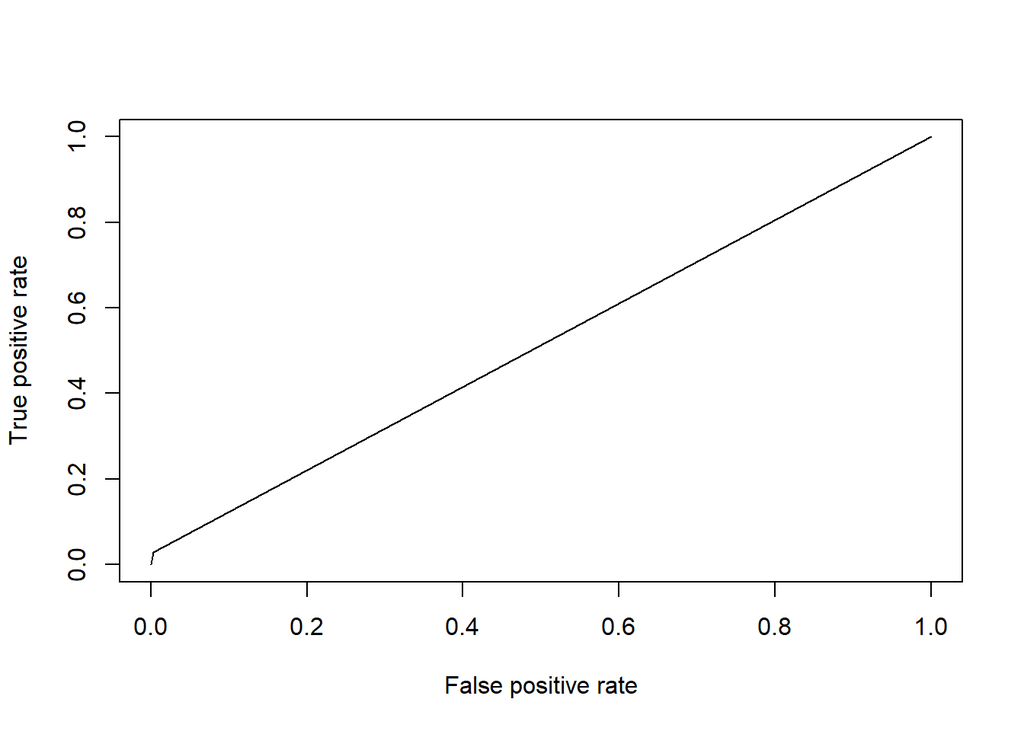

```r
#logistic regression
##cross validation, k=5
ctrl = trainControl(method = 'cv',number = 5)
newdata=na.omit(newdata)
mylogit3 = train(hospital_expire_flg~icustay_admit_age+gender+admission_type_descr+overall_payor_group_descr+ttlCode,
                 data=newdata,method='glm',family="binomial",trControl=ctrl)
lr_prediction=data.frame(preds=(mylogit3 %>% predict(newdata, type="raw")))
lr_prediction$preds2=!as.numeric(lr_prediction$preds)==1
lr_prediction=data.frame(lr_prediction$preds2)
#ROC Curve
columns_for_ROC =  # columns: predictions, labels
  newdata %>%
  select(hospital_expire_flg) %>%
  bind_cols(lr_prediction) %>% mutate(type=hospital_expire_flg=="Y")
# plot it:
prediction(predictions=as.numeric(columns_for_ROC$lr_prediction.preds2),
           labels=columns_for_ROC$type) %>%
  performance("tpr", "fpr") %>% plot()
```

```r
lr_pred = ROCR::prediction(as.numeric(columns_for_ROC$lr_prediction.preds2),columns_for_ROC$type)
lr_auc = mean(ROCR::performance(lr_pred,"auc")@y.values %>% unlist())
lr_auc
```

```
## [1] 0.5124723
```

```r
####decision tree
fit <- train(hospital_expire_flg ~ icustay_admit_age+gender+admission_type_descr+overall_payor_group_descr+ttlCode, data = newdata , method = "ctree",
             trControl = trainControl(method = "cv", number = 5),
             tuneLength=5)
fit
```

```
## Conditional Inference Tree
##
## 10807 samples
##     5 predictor
##     2 classes: 'N', 'Y'
##
## No pre-processing
## Resampling: Cross-Validated (5 fold)
## Summary of sample sizes: 8645, 8646, 8646, 8646, 8645
## Resampling results across tuning parameters:
##
##   mincriterion  Accuracy   Kappa
##   0.010         0.8115122  0.14843268
##   0.255         0.8092914  0.08898338
##   0.500         0.8090135  0.07232843
##   0.745         0.8079952  0.05762411
##   0.990         0.8098458  0.03408274
##
## Accuracy was used to select the optimal model using the largest value.
## The final value used for the model was mincriterion = 0.01.
```

```r
fit$finalModel
```

[output not shown]

[output cut: 385 more lines]

[output not shown]

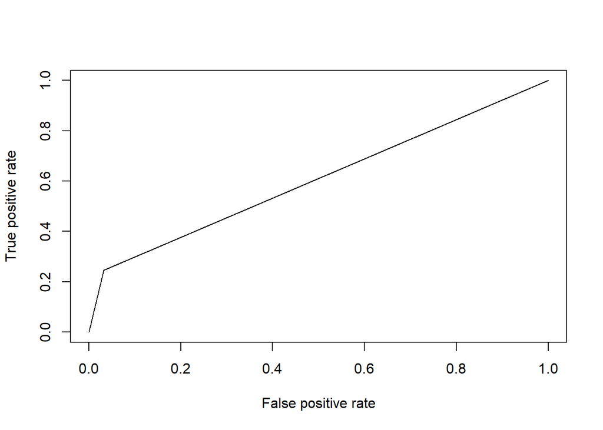

```r
tree_prediction <- predict(fit, newdata = newdata,type='raw') # prediction probabilities
tree_prediction=data.frame(preds=(fit %>% predict(newdata, type="raw")))
tree_prediction$preds2=!as.numeric(tree_prediction$preds)==1
tree_prediction=data.frame(tree_prediction$preds2)
#ROC Curve
columns_for_ROC =  # columns: predictions, labels
  newdata %>%
  select(hospital_expire_flg) %>%
  bind_cols(tree_prediction) %>% mutate(type=hospital_expire_flg=="Y")

# plot it:
prediction(predictions=as.numeric(columns_for_ROC$tree_prediction.preds2),
           labels=columns_for_ROC$type) %>%
  performance("tpr", "fpr") %>% plot()
```

```r
tree_pred = ROCR::prediction(as.numeric(columns_for_ROC$tree_prediction.preds2),columns_for_ROC$type)
tree_auc = mean(ROCR::performance(tree_pred,"auc")@y.values %>% unlist())
tree_auc
```

```
## [1] 0.6072029
```

6. Draw learning curves (y: performance measure, x: number of training samples) for logistic regression and decision tree. Does one algorithm dominate the other? If not, when does logistic regression have better performance?

```r
###learning curve

lrn_crv=data.table(size=numeric(),accuracy=double(),desc=character())

for (i in seq(3000,nrow(newdata),300)) {
  #have a new sample set
  newdata = newdata[sample(1:nrow(newdata)),]
  lr_train = newdata[1:i,]
  lr_train=na.omit(lr_train)
  lr_test = newdata[-(1:i),]
  lr_test = na.omit(lr_test)
  #conduct model
  mlr <- glm(hospital_expire_flg ~ icustay_admit_age+gender+admission_type_descr+overall_payor_group_descr+ttlCode, family = binomial("logit"), data = lr_train)
  mtree <- rpart(hospital_expire_flg ~ icustay_admit_age+gender+admission_type_descr+overall_payor_group_descr+ttlCode, data = lr_train, method = 'class')

  model_prob <- predict(mlr, lr_test, type = "response")
  lr_test <- lr_test  %>% mutate(model_pred = 1*(model_prob > .5) + 0,
                           hospital_expire_flg = 1*(hospital_expire_flg == "Y") + 0)
  lr_test <- lr_test %>% mutate(accurate = 1*(model_pred == hospital_expire_flg))
  acc=sum(lr_test$accurate)/nrow(lr_test)

  PreditionsWithClass <- predict(mtree, lr_test, type = "class")
  t <- table(predictions = PreditionsWithClass, actual = lr_test$hospital_expire_flg)
  tree_acc<-sum(diag(t))/sum(t)


  #append result into lrn_crv table
  tmp=data.table(size=i,accuracy=acc,desc="logit")
  tmp2=data.table(size=i,accuracy=tree_acc,desc="tree")
  lrn_crv=rbind(lrn_crv,tmp)
  lrn_crv=rbind(lrn_crv, tmp2)
}

summary(lrn_crv)
```

```
##       size          accuracy          desc
##  Min.   : 3000   Min.   :0.7818   Length:54
##  1st Qu.: 4875   1st Qu.:0.8063   Class :character
##  Median : 6900   Median :0.8086   Mode  :character
##  Mean   : 6900   Mean   :0.8156
##  3rd Qu.: 8925   3rd Qu.:0.8122
##  Max.   :10800   Max.   :1.0000
```

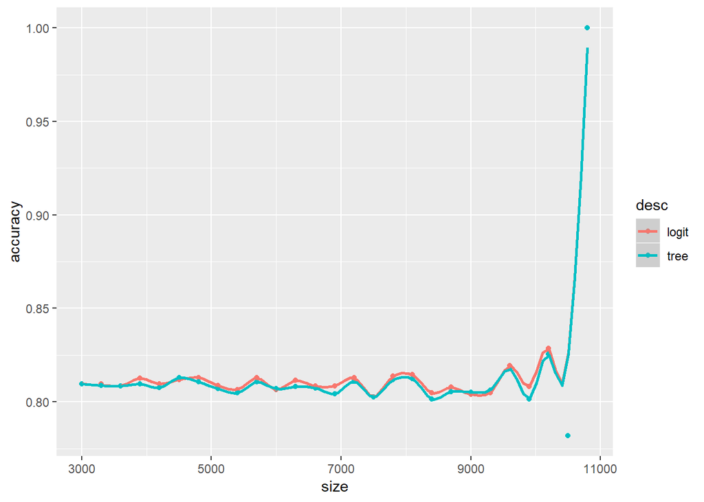

```r
p<-ggplot(lrn_crv, aes(x=size, y=accuracy, group=desc)) +
  #geom_line(aes(color=desc))+
  geom_point(aes(color=desc))+
  geom_smooth(span = 0.2,aes(color=desc))
p
```

#### Subsection 3. [3]

7. Estimate the odds and probability of in-hospital death for a patient with following features using the trained LR model from part (b). Note some of the features below may be unused.

```r
case = data.frame(icustay_admit_age=58, gender='M', admission_type_descr='URGENT', ttlCode=11)
logit=predict(mylogit, case, type="response")
odds <- exp(logit)
prob <- odds / (1 + odds)
print(c(prob,odds))
```

```
##        1        1
## 0.547133 1.208154
```

8. Divide the LR model coefficients (from (b)) by the coefficient with the smallest absolute value (call this m), and round the adjusted coefficients to have 2 significant digits, e.g. 4871 becomes 4900. Call these points. 1/m is the number of points to increase the log odds by 1.  
   Using the more human interpretable (but mathematically suboptimal) points system from the sentence above, **plot a graph with y-axis the probability of in-hospital death, and x-axis number of points** . Then, **calculate and report the probability of in-hospital death for an individual with the following features**:

```r
coef=mylogit$coefficients
m=min(abs(mylogit$coefficients))
points=signif(coef/m,digits = 2)
coef=points
points
```

```
##                   (Intercept)             icustay_admit_age
##                        -160.0                           1.0
##                       genderM admission_type_descrEMERGENCY
##                          -3.2                          15.0
##   admission_type_descrNEWBORN    admission_type_descrURGENT
##                         700.0                          25.0
##                       ttlCode
##                           1.9
```

```r
1/m
```

```
## [1] 41.11442
```

```r
for(i in 1:length(coef)){
  if(coef[i]>100){
    coef[i]=signif(coef[i],digits = 2)
  }else{
    coef[i]=round(coef[i],0)
  }
}
coef
```

```
##                   (Intercept)             icustay_admit_age
##                          -160                             1
##                       genderM admission_type_descrEMERGENCY
##                            -3                            15
##   admission_type_descrNEWBORN    admission_type_descrURGENT
##                           700                            25
##                       ttlCode
##                             2
```

```r
#points for this patient
points.patient = 76.5 * coef[1] + 1*coef[4] + 14*coef[7]
odds = exp(points.patient*m)
new.prob = odds/(1+odds)
new.prob
```

```
##   (Intercept)
## 1.452955e-129
```

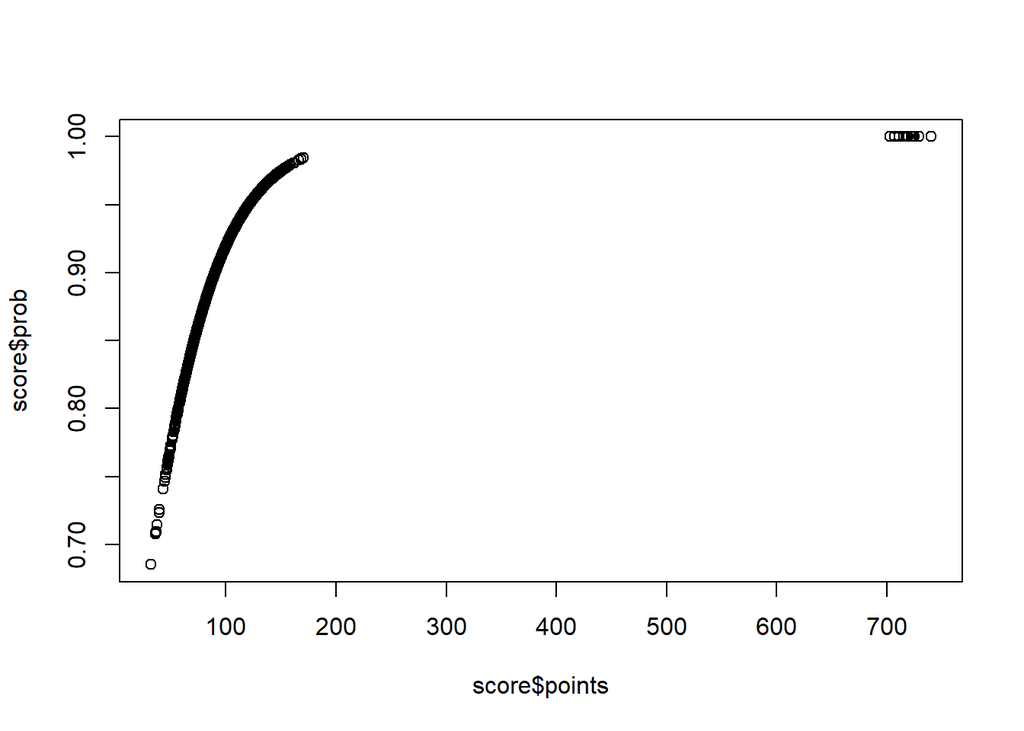

```r
#construct points system
#calculate points based on previous adjusts coefficient
points=list()
for (i in 1:length(newdata)) {
  gender_score=as.numeric(newdata$gender=='M')
  type_scr_e=as.numeric(newdata$admission_type_descr=='EMERGENCY')
  type_scr_n=as.numeric(newdata$admission_type_descr=='NEWBORN')
  type_scr_u=as.numeric(newdata$admission_type_descr=='URGENT')
  tmppoints=coef[2]*newdata$icustay_admit_age+coef[3]*gender_score+coef[4]*type_scr_e+coef[5]*type_scr_n+coef[6]*type_scr_u+coef[7]*newdata$ttlCode
  points[[i]]=tmppoints
}
points=data.frame(points)[1]
setnames(points, c("points") )

prob = list()
for(i in 1:length(points)){
  p = points[i]*m
  odds = exp(p)
  prob[[i]] = odds/(1+odds)
}

score = data.frame(cbind(prob,points))
setnames(score,c("prob","points"))

plot(score$points,score$prob)
```